# Assignment 1

Group 11

2026-10-08

# Part B: Synthetic Data

# 1. Introduction

In this part, we generate synthetic data for the proposed study. The study investigates whether adding a human demonstration to a text instruction affects the time an embodied AI robot needs to complete a manipulation task.

The **independent variable** is the instruction condition: - Text-only - Text + demonstration

The **dependent variable** is task completion time, measured in seconds.

We generate two datasets:

1. A dataset in which a true effect exists.
2. A dataset in which the null hypothesis is true.

The effect of the human demonstration is controlled by an adjustable parameter called `effect_size`.

# 2. Load packages

```r
# Load the packages needed for data manipulation and visualisation
library(tidyverse)
```

# 3. Set seed and Define simulation parameters

```r
# Set a seed to for reproducibility
set.seed(42)

# Total number of robot trials
N <- 100

# Number of trials in each experimental condition
n_per_group <- N / 2

# Mean completion time for the text-only condition, in seconds
mean_text <- 30

# Standard deviation of completion time within each condition, in seconds
sd_completion <- 5

# True effect of adding a human demonstration
# A negative value means that the demonstration is expected to
# reduce completion time
# For example, -3 means that the demonstration reduces the
# population mean completion time by 3 seconds
effect_size <- -3

# Mean completion time in the demonstration condition
mean_demo <- mean_text + effect_size
```

# 4.1 Simulate the dataset with a true effect

```r
# Generate completion times for robots receiving the text-only instruction
# rnorm() draws random observations from a normal distribution.
# The distribution has a mean of 30 seconds and an SD of 5 seconds
text_effect <- rnorm(
  n = n_per_group,
  mean = mean_text,
  sd = sd_completion
)

# Generate completion times for robots receiving both the text instruction
# and a human demonstration
# The mean is lower by the specified effect size (-3 seconds)
demo_alternative <- rnorm(
  n = n_per_group,
  mean = mean_demo,
  sd = sd_completion
)

# Combine the two groups into one data frame
data_alternative <- tibble(
  condition = c(
    rep("Text-only", n_per_group),
    rep("Text + demonstration", n_per_group)
  ),
  completion_time = c(
    text_effect,
    demo_alternative
  )
)

# Completion time cannot be negative in reality
# We therefore replace any negative simulated values with zero
data_alternative <- data_alternative %>%
  mutate(
    completion_time = pmax(completion_time, 0)
  )

# Display the first few observations
head(data_alternative)
```

```
## # A tibble: 6 × 2
##   condition completion_time
##   <chr>               <dbl>
## 1 Text-only            36.9
## 2 Text-only            27.2
## 3 Text-only            31.8
## 4 Text-only            33.2
## 5 Text-only            32.0
## 6 Text-only            29.5
```

# 4.2 Inspect the simulated effect dataset

```r
# Calculate descriptive statistics for each experimental condition
data_alternative %>%
  group_by(condition) %>%
  summarise(
    n = n(),
    mean = mean(completion_time),
    sd = sd(completion_time),
    min = min(completion_time),
    max = max(completion_time)
  )
```

```
## # A tibble: 2 × 6
##   condition                n  mean    sd   min   max
##   <chr>                <int> <dbl> <dbl> <dbl> <dbl>
## 1 Text + demonstration    50  27.5  4.62  12.0  34.9
## 2 Text-only               50  29.8  5.76  16.7  41.4
```

# 5.1 Simulate the dataset under null hypothesis

```r
# For the null dataset, we set the true effect to zero, which means that
# the population mean completion time is identical in the two conditions
null_effect <- 0

# Calculate the mean completion time for the demonstration condition
# under the null hypothesis
mean_demo_null <- mean_text + null_effect

# Generate completion times for the text-only condition
text_null <- rnorm(
  n = n_per_group,
  mean = mean_text,
  sd = sd_completion
)

# Generate completion times for the demonstration condition
# Since null_effect = 0, both groups have the same population mean
demo_null <- rnorm(
  n = n_per_group,
  mean = mean_demo_null,
  sd = sd_completion
)

# Combine the two groups into one data frame
data_null <- tibble(
  condition = c(
    rep("Text-only", n_per_group),
    rep("Text + demonstration", n_per_group)
  ),
  completion_time = c(
    text_null,
    demo_null
  )
)

# Ensure that completion times cannot be negative
data_null <- data_null %>%
  mutate(
    completion_time = pmax(completion_time, 0)
  )

# Display the first few observations
head(data_null)
```

```
## # A tibble: 6 × 2
##   condition completion_time
##   <chr>               <dbl>
## 1 Text-only            36.0
## 2 Text-only            35.2
## 3 Text-only            25.0
## 4 Text-only            39.2
## 5 Text-only            26.7
## 6 Text-only            30.5
```

# 5.2 Inspect the null dataset

```r
# Calculate descriptive statistics for each condition:
# Even though the population means are identical, the sample means
# will usually differ slightly because of random sampling variation
data_null %>%
  group_by(condition) %>%
  summarise(
    n = n(),
    mean = mean(completion_time),
    sd = sd(completion_time),
    min = min(completion_time),
    max = max(completion_time)
  )
```

```
## # A tibble: 2 × 6
##   condition                n  mean    sd   min   max
##   <chr>                <int> <dbl> <dbl> <dbl> <dbl>
## 1 Text + demonstration    50  29.9  4.42  21.3  39.1
## 2 Text-only               50  29.2  4.64  19.9  43.5
```

# 6. Visualize the dataset with a true effect

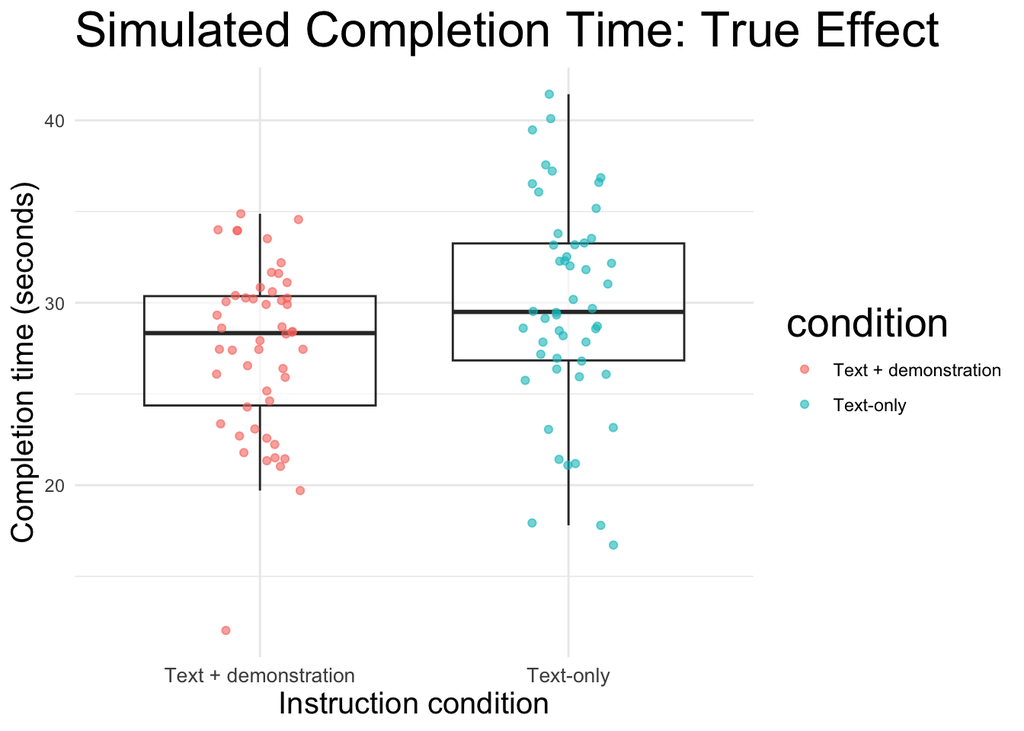

```r
# Plot the distribution of completion times in the two conditions:

# Individual observations are shown as points
# the boxplots summarise the distribution within each condition.
ggplot(
  data_alternative,
  aes(
    x = condition,
    y = completion_time
  )
) +
  geom_boxplot(outlier.shape = NA, alpha = 0.6) +
  geom_jitter(aes(colour = condition), width = 0.15, alpha = 0.6) +
  labs(
    title = "Simulated Completion Time: True Effect",
    x = "Instruction condition",
    y = "Completion time (seconds)"
  ) +
  theme_minimal() +
  theme(title = element_text(size = 20)) +
  theme(axis.text.x = element_text(size = 10)) +
  theme(axis.title = element_text(size = 15))
```

# 7. Visualize the null dataset

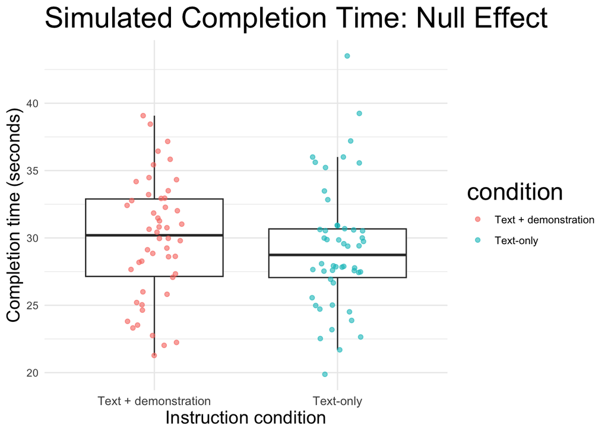

```r
# Visualise the completion times under the null hypothesis:
# The two groups should overlap substantially because their population
# means are identical.
ggplot(
  data_null,
  aes(
    x = condition,
    y = completion_time
  )
) +
  geom_boxplot(outlier.shape = NA) +
  geom_jitter(aes(colour = condition), width = 0.15, alpha = 0.6) +
  labs(
    title = "Simulated Completion Time: Null Effect",
    x = "Instruction condition",
    y = "Completion time (seconds)"
  ) +
  theme_minimal() +
  theme(title = element_text(size = 20)) +
  theme(axis.text.x = element_text(size = 10)) +
  theme(axis.title = element_text(size = 15))
```

# 8. Compare the two conditions statistically

```r
# Perform the planned independent-samples two-sided t-test
# on the dataset containing a true effect:
# The test compares mean completion time between the two
# instruction conditions
t_test_effect <- t.test(
  completion_time ~ condition,
  data = data_alternative,
  alternative = "two.sided"
)

# Display the results.
t_test_effect
```

```
##
##  Welch Two Sample t-test
##
## data:  completion_time by condition
## t = -2.2196, df = 93.647, p-value = 0.02886
## alternative hypothesis: true difference in means between group Text + demonstration and group Text-only is not equal to 0
## 95 percent confidence interval:
##  -4.3918920 -0.2443761
## sample estimates:
## mean in group Text + demonstration            mean in group Text-only
##                           27.50351                           29.82164
```

```r
# Perform the same planned two-sided t-test on the null dataset:
# Here the true population effect is zero, so any observed
# difference between the sample means is due to random variation.
t_test_null <- t.test(
  completion_time ~ condition,
  data = data_null,
  alternative = "two.sided"
)

# Display the results.
t_test_null
```

```
##
##  Welch Two Sample t-test
##
## data:  completion_time by condition
## t = 0.70345, df = 97.783, p-value = 0.4834
## alternative hypothesis: true difference in means between group Text + demonstration and group Text-only is not equal to 0
## 95 percent confidence interval:
##  -1.161274  2.436622
## sample estimates:
## mean in group Text + demonstration            mean in group Text-only
##                           29.88142                           29.24374
```

```r
# Calculate the observed mean difference explicitly
# The effect is defined as:
# mean(Text + demonstration) - mean(Text-only).
effect_estimate <- mean(
  data_alternative$completion_time[data_alternative$condition == "Text + demonstration"]
) -
  mean(
    data_alternative$completion_time[data_alternative$condition == "Text-only"]
  )

# Calculate the same observed effect for the null dataset.
effect_estimate_null <- mean(
  data_null$completion_time[data_null$condition == "Text + demonstration"]
) -
  mean(
    data_null$completion_time[data_null$condition == "Text-only"]
  )

effect_estimate
```

```
## [1] -2.318134
```

```r
effect_estimate_null
```

```
## [1] 0.6376738
```

# Part C: Simulated Data

# 1. Introduction

In Part B, two simulated datasets were generated to represent two possible situations: one in which adding a human demonstration has a true effect on task completion time, and one in which there is no true effect. In this part, the statistical analysis is first applied to these two datasets.

The analysis uses a two-sided Welch two-sample t-test to compare mean completion time between the text-only and text + demonstration conditions. The mean difference is defined as the mean completion time in the demonstration condition minus the mean completion time in the text-only condition.

The analysis is then **repeated over 10,000 independently simulated studies**. This allows us to examine how much the estimated effect and p-value vary from study to study, and to estimate the Type I error rate, Type II error rate, and statistical power of the test.

# 2. Assumption check

```r
# load the packages for drawing better qqplot
library(qqplotr)
```

# 2.1 Histogram and QQplot for Alternative dataset

```r
model_alternative <- lm(
  completion_time ~ condition,
  data = data_alternative
)

data_alternative$residuals <- residuals(model_alternative)
```

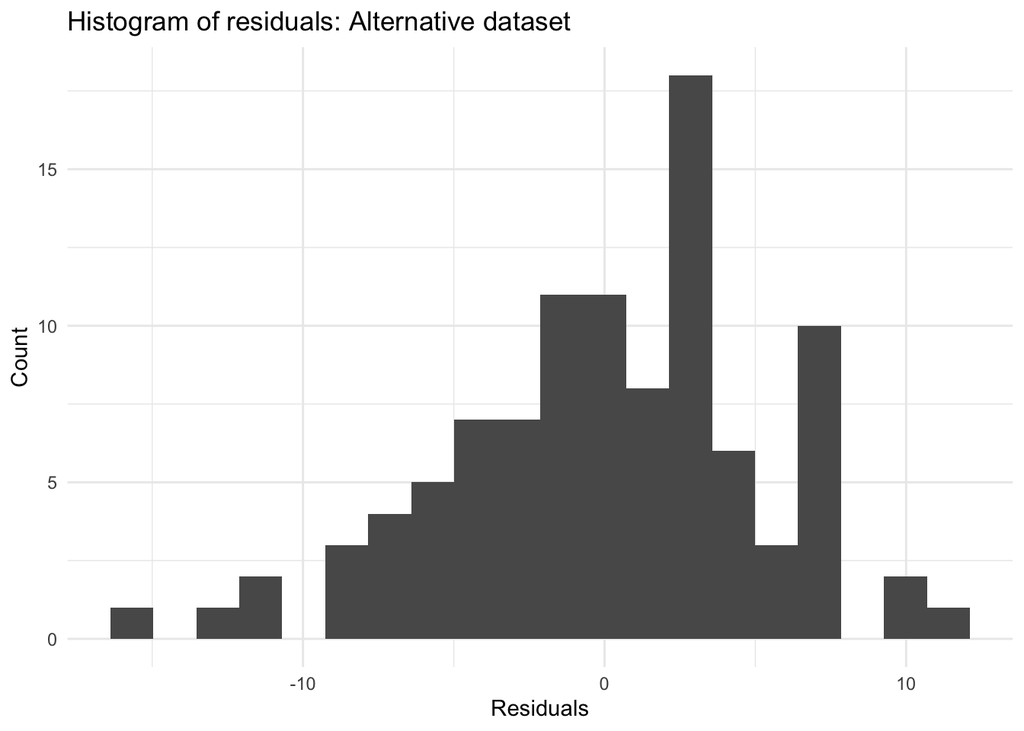

```r
ggplot(
  data_alternative,
  aes(x = residuals)
) +
  geom_histogram(bins = 20) +
  labs(
    title = "Histogram of residuals: Alternative dataset",
    x = "Residuals",
    y = "Count"
  ) +
  theme_minimal()
```

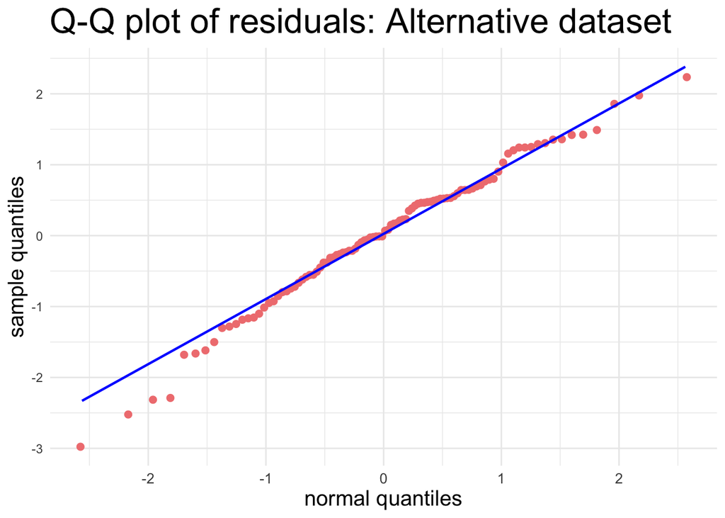

```r
ggplot(
  data_alternative,
  aes(sample = scale(residuals))
) +
  stat_qq(color = "lightcoral", size = 2) +
  stat_qq_line(color = "blue", linewidth = 0.8) +
  labs(
    title = "Q-Q plot of residuals: Alternative dataset",
    x = "normal quantiles",
    y = "sample quantiles"
  ) +
  theme_minimal() +
  theme(title = element_text(size = 20)) +
  theme(axis.text.x = element_text(size = 10)) +
  theme(axis.title = element_text(size = 15))
```

## The result shows that the residuals are approximately linear

# 2.2 The same check for null dataset

```r
model_null <- lm(completion_time ~ condition, data = data_null)

data_null$residuals <- residuals(model_null)
```

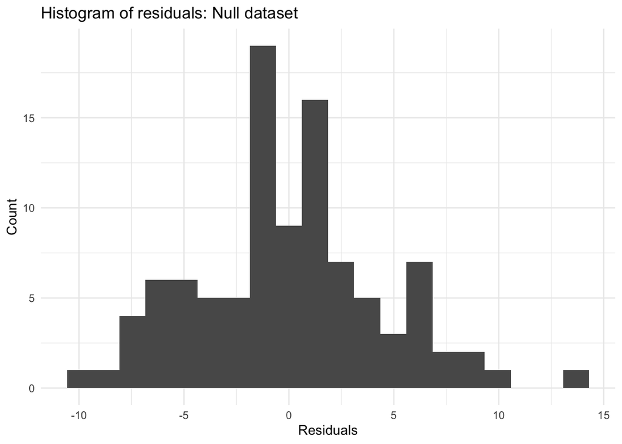

```r
ggplot(
  data_null,
  aes(x = residuals)
) +
  geom_histogram(bins = 20) +
  labs(
    title = "Histogram of residuals: Null dataset",
    x = "Residuals",
    y = "Count"
  ) +
  theme_minimal()
```

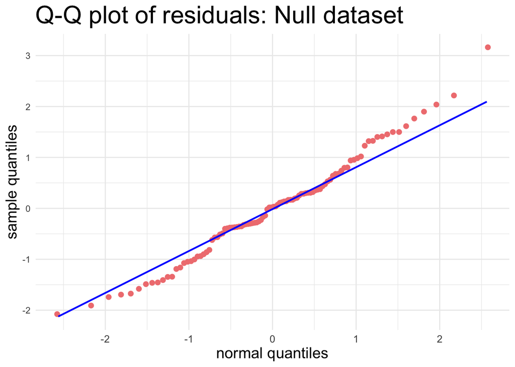

```r
ggplot(
  data_null,
  aes(sample = scale(residuals))
) +
  stat_qq(color = "lightcoral", size = 2) +
  stat_qq_line(color = "blue", linewidth = 0.8) +
  labs(
    title = "Q-Q plot of residuals: Null dataset",
    x = "normal quantiles",
    y = "sample quantiles"
  ) +
  theme_minimal() +
  theme(title = element_text(size = 20)) +
  theme(axis.text.x = element_text(size = 10)) +
  theme(axis.title = element_text(size = 15))
```

## Again, normally distributed

# 3. Simulation

```r
# Set the number of simulated studies
set.seed(123)
n_studies <- 10000
```

# 3.1 Alternative hypothesis simulation

```r
# Create an empty data frame to store the results from every simulated study
alternative_results <- tibble(
  study = integer(),
  p_value = numeric(),
  estimated_effect = numeric()
)

# Repeat the complete study many times
for (i in 1:n_studies) {

  # Generate 50 completion times for the Text-only condition
  text_times <- rnorm(
    n = n_per_group,
    mean = mean_text,
    sd = sd_completion
  )

  # Generate 50 completion times for the demonstration condition
  # The true mean is 30 + (-3) = 27 seconds.
  demo_times <- rnorm(
    n = n_per_group,
    mean = mean_text + effect_size,
    sd = sd_completion
  )

  # Prevent physically impossible negative completion times
  text_times <- pmax(text_times, 0)
  demo_times <- pmax(demo_times, 0)

  # Combine the two groups into one dataset
  simulated_data <- tibble(
    condition = c(
      rep("Text-only", n_per_group),
      rep("Text + demonstration", n_per_group)
    ),
    completion_time = c(
      text_times,
      demo_times
    )
  )

  # Run the planned two-sided Welch t-test
  test_result <- t.test(
    completion_time ~ condition,
    data = simulated_data,
    alternative = "two.sided"
  )

  # Calculate the estimated effect explicitly as:
  # mean(Text + demonstration) - mean(Text-only).
  estimated_effect <- mean(demo_times) - mean(text_times)

  # Store the p-value and estimated effect from this study
  alternative_results <- bind_rows(
    alternative_results,
    tibble(
      study = i,
      p_value = test_result$p.value,
      estimated_effect = estimated_effect
    )
  )
}
```

# 3.2 Null hypothesis simulation

```r
# Create an empty data frame to store the results from every simulated study
null_results <- tibble(
  study = integer(),
  p_value = numeric(),
  estimated_effect = numeric()
)

# Repeat the complete study many times under the null hypothesis
for (i in 1:n_studies) {

  # Generate 50 completion times for the Text-only condition
  text_times <- rnorm(
    n = n_per_group,
    mean = mean_text,
    sd = sd_completion
  )

  # Generate 50 completion times for the demonstration condition
  # Because the true effect is zero, its population mean is also 30
  demo_times <- rnorm(
    n = n_per_group,
    mean = mean_text + null_effect,
    sd = sd_completion
  )

  # Prevent physically impossible negative completion times.
  text_times <- pmax(text_times, 0)
   demo_times <- pmax(demo_times, 0)
  # Combine both conditions into one dataset.
  simulated_data <- tibble(
    condition = c(
      rep("Text-only", n_per_group),
      rep("Text + demonstration", n_per_group)
    ),
    completion_time = c(
      text_times,
      demo_times
    )
  )

  # Run the same two-sided Welch t-test.
  test_result <- t.test(
    completion_time ~ condition,
    data = simulated_data,
    alternative = "two.sided"
  )

  # Calculate the observed effect for this simulated study.
  estimated_effect <- mean(demo_times) - mean(text_times)

  # Store the p-value and estimated effect.
  null_results <- bind_rows(
    null_results,
    tibble(
      study = i,
      p_value = test_result$p.value,
      estimated_effect = estimated_effect
    )
  )
}
```

# 4. Type 1 Error, Type 2 Error and Power

```r
# Calculate the Type I error rate:
# Under the null hypothesis, a significant result (p < .05)
# represents a Type I error
type_I_error <- mean(null_results$p_value < 0.05)

type_I_error
```

```
## [1] 0.0492
```

```r
# Calculate the Type II error rate:
# This is the proportion of studies under the alternative
# hypothesis where the true effect was not detected.
type_II_error <- mean(alternative_results$p_value >= 0.05)

type_II_error
```

```
## [1] 0.1601
```

```r
# Calculate statistical power:
# Under the alternative hypothesis, a significant result
# means that the true effect was detected.
power <- mean(alternative_results$p_value < 0.05)

power
```

```
## [1] 0.8399
```

```r
# check: Type II error and power should add up to approximately 1
type_II_error + power
```

```
## [1] 1
```

```r
# Create a summary table of the main simulation results:
simulation_summary <- tibble(
  measure = c(
    "Type I error",
    "Type II error",
    "Statistical power"
  ),
  estimate = c(
    type_I_error,
    type_II_error,
    power
  )
)

simulation_summary
```

```
## # A tibble: 3 × 2
##   measure           estimate
##   <chr>                <dbl>
## 1 Type I error        0.0492
## 2 Type II error       0.160
## 3 Statistical power   0.840
```

# 5. P-value distributions

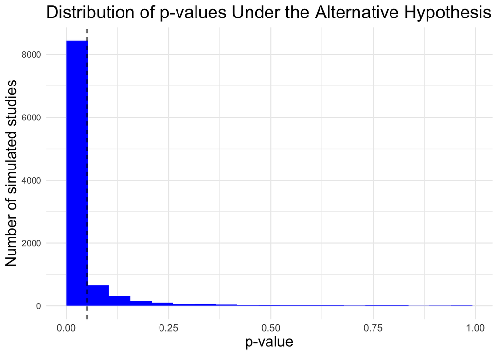

```r
# Plot the distribution of p-values under the alternative hypothesis.
# The dashed line marks the significance threshold of 0.05.
ggplot(alternative_results, aes(x = p_value)) +
  geom_histogram(bins = 20,
                 boundary = 0,
                 fill = "blue") +
  geom_vline(
    xintercept = 0.05,
    linetype = "dashed"
  ) +
  labs(
    title = "Distribution of p-values Under the Alternative Hypothesis",
    x = "p-value",
    y = "Number of simulated studies"
  ) +
  theme_minimal() +
  theme(title = element_text(size = 15)) +
  theme(axis.text.x = element_text(size = 10)) +
  theme(axis.title = element_text(size = 15))
```

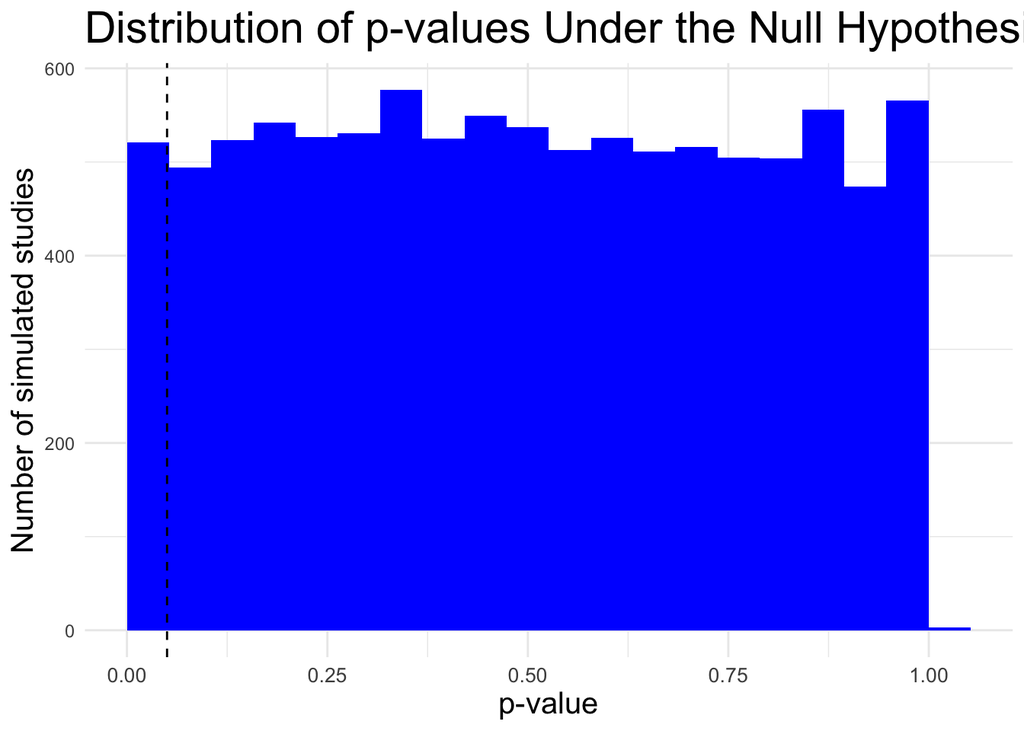

```r
# Plot the distribution of p-values under the null hypothesis
# The dashed line marks the significance threshold of 0.05:
ggplot(null_results, aes(x = p_value)) +
  geom_histogram(bins = 20,
                 bindwidth = 0.05,
                 boundary = 0,
                 fill = "blue") +
  geom_vline(
    xintercept = 0.05,
    linetype = "dashed"
  ) +
  labs(
    title = "Distribution of p-values Under the Null Hypothesis",
    x = "p-value",
    y = "Number of simulated studies"
  ) +
  theme_minimal() +
  theme(title = element_text(size = 18)) +
  theme(axis.text.x = element_text(size = 10)) +
  theme(axis.title = element_text(size = 15))
```

# 6. Estimated-effects distributions

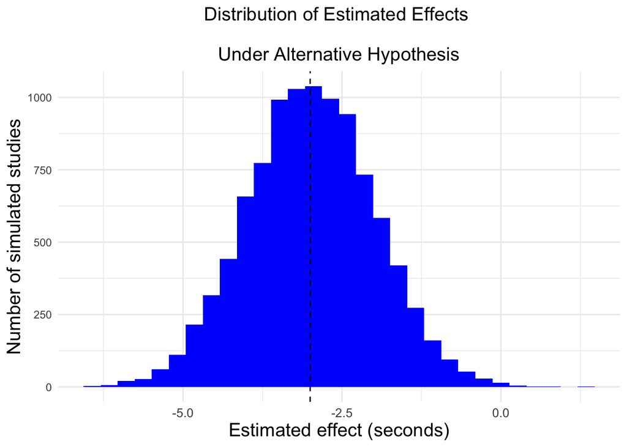

```r
# Plot the distribution of estimated effects across simulated studies
# The vertical line shows the true effect of -3 seconds:
ggplot(alternative_results, aes(x = estimated_effect)) +
  geom_histogram(bins = 30,
                 fill = "blue") +
  geom_vline(
    xintercept = -3,
    linetype = "dashed"
  ) +
  labs(
    title = "Distribution of Estimated Effects
    \nUnder Alternative Hypothesis",
    x = "Estimated effect (seconds)",
    y = "Number of simulated studies"
  ) +
  theme_minimal() +
  theme(plot.title = element_text(size = 15, hjust = 0.5)) +
  theme(axis.text.x = element_text(size = 10)) +
  theme(axis.title = element_text(size = 15))
```

```r
mean(alternative_results$estimated_effect)
```

```
## [1] -2.989953
```

```r
sd(alternative_results$estimated_effect)
```

```
## [1] 0.9950964
```

```r
quantile(alternative_results$estimated_effect, c(.025, .975))
```

```
##      2.5%     97.5%
## -4.930234 -1.048890
```

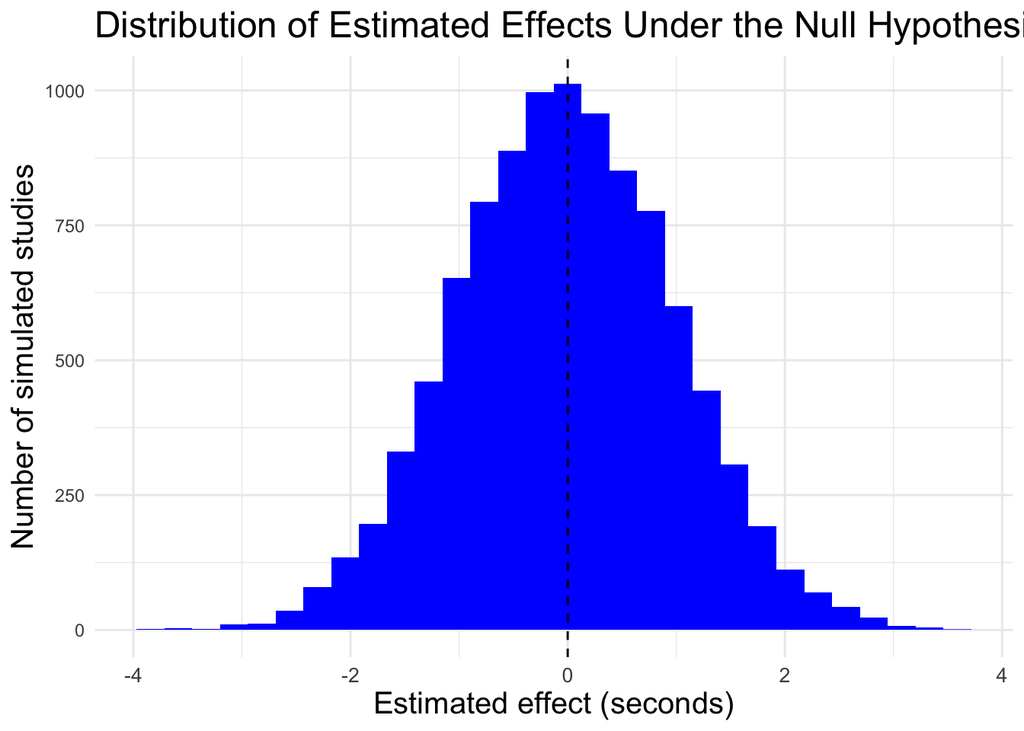

```r
# Plot the distribution of estimated effects under the null hypothesis
# The true effect is zero, so the distribution should be centred
# approximately around zero
ggplot(null_results, aes(x = estimated_effect)) +
  geom_histogram(bins = 30,
                 fill = "blue") +
  geom_vline(
    xintercept = 0,
    linetype = "dashed"
  ) +
  labs(
    title = "Distribution of Estimated Effects Under the Null Hypothesis",
    x = "Estimated effect (seconds)",
    y = "Number of simulated studies"
  ) +
  theme_minimal() +
  theme(title = element_text(size = 15)) +
  theme(axis.text.x = element_text(size = 10)) +
  theme(axis.title = element_text(size = 15))
```

# 7. Different sample sizes

```r
set.seed(123)
sample_sizes <- c(25, 100, 200, 500)

# Number of studies used for each sample size.
n_power_studies <- 2000

# Create an empty data frame to store the results.
power_by_n <- tibble(
  n_per_group = integer(),
  power = numeric()
)

# Repeat the simulation for each sample size.
for (n_current in sample_sizes) {

  # Store whether each simulated study produced a significant result.
  significant_results <- numeric(n_power_studies)

  for (i in 1:n_power_studies) {

    # Generate Text-only completion times.
    text_times <- rnorm(
      n = n_current,
      mean = mean_text,
      sd = sd_completion
    )

    # Generate demonstration completion times under
    # the true effect of -3 seconds.
    demo_times <- rnorm(
      n = n_current,
      mean = mean_text + effect_size,
      sd = sd_completion
    )

    # Prevent negative completion times.
    text_times <- pmax(text_times, 0)
    demo_times <- pmax(demo_times, 0)

    # Combine both groups.
    simulated_data <- tibble(
      condition = c(
        rep("Text-only", n_current),
        rep("Text + demonstration", n_current)
      ),
      completion_time = c(
        text_times,
        demo_times
      )
    )

    # Run the two-sided Welch t-test.
    test_result <- t.test(
      completion_time ~ condition,
      data = simulated_data,
      alternative = "two.sided"
    )

    # Record whether the result was statistically significant.
    significant_results[i] <- test_result$p.value < 0.05
  }

  # Calculate power for this sample size.
  power_by_n <- bind_rows(
    power_by_n,
    tibble(
      n_per_group = n_current,
      power = mean(significant_results)
    )
  )
}

power_by_n
```

```
## # A tibble: 4 × 2
##   n_per_group power
##         <dbl> <dbl>
## 1          25 0.556
## 2         100 0.991
## 3         200 1
## 4         500 1
```

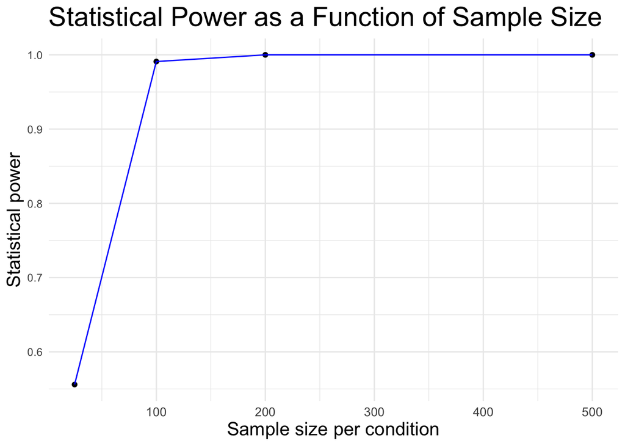

```r
# Visualise how statistical power changes with sample size.
ggplot(power_by_n, aes(x = n_per_group, y = power)) +
  geom_point() +
  geom_line(color = "blue") +
  labs(
    title = "Statistical Power as a Function of Sample Size",
    x = "Sample size per condition",
    y = "Statistical power"
  ) +
  theme_minimal() +
  theme(title = element_text(size = 18)) +
  theme(axis.text.x = element_text(size = 10)) +
  theme(axis.title = element_text(size = 15))
```

# Part D: Simulation with QRPs

# 1. Introduction

In Part D, two questionable research practices (QRPs) are introduced to examine how they can affect the results of the same simulated study. The two QRPs are selective reporting between the test of with or without outlier removal; and rounding down p-values.

The two QRPs are simulated separately. For QRP1, two analyses are performed for each simulated study. First, the original data are analysed using the Welch two-sample t-test. Second, observations identified as potential outliers using the 1.5$\times$IQR rule are removed, and the Welch two-sample t-test is performed again. The two resulting p-values are then compared, and the smaller p-value is selected as the reported result. This QRP was chosen because potential outliers were observed in the boxplots in Part B. Importantly, the questionable practice is not the removal of outliers itself, but the selective reporting of the analysis that produces the more favourable statistical result.

For QRP2, the original p-values are rounded down to two decimal places and the rounded values are used for significance decisions. This QRP was chosen to examine how changing p-values near the 0.05 significance threshold can increase the number of results classified as significant.

Each QRP is repeated over 10,000 independently simulated studies under both the alternative and null hypotheses. The results are compared with Part C to examine changes in p-values, estimated effects, Type I error, Type II error, and statistical power.

# 2. QRP-1: Selectively excluding data

# 2.1 Alerternative hypothesis simulation

```r
# Number of simulated studies
set.seed(123)
n_studies_qrp <- 10000
```

```r
# Create an empty data frame to store the results
alternative_outlier_results <- tibble(
  study = integer(),
  p_value_original = numeric(),
  p_value_outlier = numeric(),
  p_value_reported = numeric(),
  estimated_effect_original = numeric(),
  estimated_effect_outlier = numeric(),
  estimated_effect_reported = numeric(),
  n_removed = integer()
)

# Repeat the complete study many times
for (i in 1:n_studies_qrp) {

  # Generate completion times for the Text-only condition
  text_times <- rnorm(
    n = n_per_group,
    mean = mean_text,
    sd = sd_completion
  )

  # Generate completion times for the demonstration condition
  demo_times <- rnorm(
    n = n_per_group,
    mean = mean_text + effect_size,
    sd = sd_completion
  )

  # Prevent physically impossible negative completion times
  text_times <- pmax(text_times, 0)
  demo_times <- pmax(demo_times, 0)

  # Create the original dataset
  original_data <- tibble(
    condition = c(
      rep("Text-only", n_per_group),
      rep("Text + demonstration", n_per_group)
    ),
    completion_time = c(
      text_times,
      demo_times
    )
  )

  # Test the original, unprocessed data
  original_test <- t.test(
    completion_time ~ condition,
    data = original_data,
    alternative = "two.sided"
  )

  estimated_effect_original <- mean(demo_times) - mean(text_times)

  # Identify outliers separately within each condition
  text_Q1 <- quantile(text_times, 0.25)
  text_Q3 <- quantile(text_times, 0.75)
  text_IQR <- text_Q3 - text_Q1

  demo_Q1 <- quantile(demo_times, 0.25)
  demo_Q3 <- quantile(demo_times, 0.75)
  demo_IQR <- demo_Q3 - demo_Q1

  # Define the outlier boundaries
  text_lower <- text_Q1 - 1.5 * text_IQR
  text_upper <- text_Q3 + 1.5 * text_IQR
  demo_lower <- demo_Q1 - 1.5 * demo_IQR
  demo_upper <- demo_Q3 + 1.5 * demo_IQR

  # Remove observations classified as outliers
  text_times_clean <- text_times[
    text_times >= text_lower &
    text_times <= text_upper
  ]

  demo_times_clean <- demo_times[
    demo_times >= demo_lower &
    demo_times <= demo_upper
  ]

  # Count the number of removed observations
  n_removed <- (
    length(text_times) - length(text_times_clean)
  ) + (
    length(demo_times) - length(demo_times_clean)
  )

  # Combine the cleaned data
  outlier_data <- tibble(
    condition = c(
      rep("Text-only", length(text_times_clean)),
      rep("Text + demonstration", length(demo_times_clean))
    ),
    completion_time = c(
      text_times_clean,
      demo_times_clean
    )
  )

  # Run the Welch t-test after removing outliers
  outlier_test <- t.test(
    completion_time ~ condition,
    data = outlier_data,
    alternative = "two.sided"
  )

  # Calculate the estimated effect after outlier removal
  estimated_effect_outlier <- (
    mean(demo_times_clean) -
    mean(text_times_clean)
  )

  # Selectively report whichever analysis gives
  # the smaller p-value
  if (outlier_test$p.value < original_test$p.value) {
    reported_p_value <- outlier_test$p.value
    estimated_effect_reported <- estimated_effect_outlier
  } else {
    reported_p_value <- original_test$p.value
    estimated_effect_reported <- estimated_effect_original
  }

  # Store the results
  alternative_outlier_results <- bind_rows(
    alternative_outlier_results,
    tibble(
      study = i,
      p_value_original = original_test$p.value,
      p_value_outlier = outlier_test$p.value,
      p_value_reported = reported_p_value,
      estimated_effect_original = estimated_effect_original,
      estimated_effect_outlier = estimated_effect_outlier,
      estimated_effect_reported = estimated_effect_reported,
      n_removed = n_removed
    )
  )
}
```

# 2.2 Null hypothesis simulation

```r
# Create an empty data frame to store the results
null_outlier_results <- tibble(
  study = integer(),
  p_value_original = numeric(),
  p_value_outlier = numeric(),
  p_value_reported = numeric(),
  estimated_effect_original = numeric(),
  estimated_effect_outlier = numeric(),
  estimated_effect_reported = numeric(),
  n_removed = integer()
)

for (i in 1:n_studies_qrp) {

  # Generate completion times for the Text-only condition
  text_times <- rnorm(
    n = n_per_group,
    mean = mean_text,
    sd = sd_completion
  )

  # Generate completion times for the demonstration condition
  # Under the null hypothesis, the true effect is zero
  demo_times <- rnorm(
    n = n_per_group,
    mean = mean_text + null_effect,
    sd = sd_completion
  )

  # Prevent physically impossible negative completion times
  text_times <- pmax(text_times, 0)
  demo_times <- pmax(demo_times, 0)

  # Create the original dataset
  original_data <- tibble(
    condition = c(
      rep("Text-only", n_per_group),
      rep("Text + demonstration", n_per_group)
    ),
    completion_time = c(
      text_times,
      demo_times
    )
  )

  # Test the original, unprocessed data
  original_test <- t.test(
    completion_time ~ condition,
    data = original_data,
    alternative = "two.sided"
  )

  estimated_effect_original <- mean(demo_times) - mean(text_times)

  # Identify outliers separately within each condition
  text_Q1 <- quantile(text_times, 0.25)
  text_Q3 <- quantile(text_times, 0.75)
  text_IQR <- text_Q3 - text_Q1

  demo_Q1 <- quantile(demo_times, 0.25)
  demo_Q3 <- quantile(demo_times, 0.75)
  demo_IQR <- demo_Q3 - demo_Q1

  # Define the outlier boundaries
  text_lower <- text_Q1 - 1.5 * text_IQR
  text_upper <- text_Q3 + 1.5 * text_IQR

  demo_lower <- demo_Q1 - 1.5 * demo_IQR
  demo_upper <- demo_Q3 + 1.5 * demo_IQR

  # Remove observations classified as outliers
  text_times_clean <- text_times[
    text_times >= text_lower &
    text_times <= text_upper
  ]

  demo_times_clean <- demo_times[
    demo_times >= demo_lower &
    demo_times <= demo_upper
  ]

  # Count the number of removed observations
  n_removed <- (
    length(text_times) - length(text_times_clean)
  ) + (
    length(demo_times) - length(demo_times_clean)
  )

  # Combine the cleaned data
  outlier_data <- tibble(
    condition = c(
      rep("Text-only", length(text_times_clean)),
      rep("Text + demonstration", length(demo_times_clean))
    ),
    completion_time = c(
      text_times_clean,
      demo_times_clean
    )
  )

  # Run the Welch t-test after removing outliers
  outlier_test <- t.test(
    completion_time ~ condition,
    data = outlier_data,
    alternative = "two.sided"
  )

  # Calculate the estimated effect after outlier removal
  estimated_effect_outlier <-
    mean(demo_times_clean) - mean(text_times_clean)

  # Selectively report whichever analysis gives
  # the smaller p-value
  if (outlier_test$p.value < original_test$p.value) {
    reported_p_value <- outlier_test$p.value
    estimated_effect_reported <- estimated_effect_outlier
  } else {
    reported_p_value <- original_test$p.value
    estimated_effect_reported <- estimated_effect_original
  }

  # Store the results
  null_outlier_results <- bind_rows(
    null_outlier_results,
    tibble(
      study = i,
      p_value_original = original_test$p.value,
      p_value_outlier = outlier_test$p.value,
      p_value_reported = reported_p_value,
      estimated_effect_original = estimated_effect_original,
      estimated_effect_outlier = estimated_effect_outlier,
      estimated_effect_reported = estimated_effect_reported,
      n_removed = n_removed
    )
  )
}
```

# 2.3 Type I error, Type II error and Power

```r
# Type I error:
# Under the null hypothesis, this is the proportion of studies
# in which the selectively reported p-value is significant
type_I_error_outlier <- mean(
  null_outlier_results$p_value_reported < 0.05
)

# Type II error:
# Under the alternative hypothesis, this is the proportion
# of studies in which the selectively reported p-value
# is not significant
type_II_error_outlier <- mean(
  alternative_outlier_results$p_value_reported >= 0.05
)

# Statistical power:
# Under the alternative hypothesis, this is the proportion
# of studies in which the selectively reported p-value
# is significant
power_outlier <- mean(
  alternative_outlier_results$p_value_reported < 0.05
)

type_I_error_outlier
```

```
## [1] 0.0776
```

```r
type_II_error_outlier
```

```
## [1] 0.1327
```

```r
power_outlier
```

```
## [1] 0.8673
```

```r
# check: Type II error and power should add up to approximately 1
type_II_error_outlier + power_outlier
```

```
## [1] 1
```

```r
# Create a summary table of the main simulation results:
outlier_summary <- tibble(
  measure = c(
    "Type I error",
    "Type II error",
    "Statistical power"
  ),
  Part_C = c(
    type_I_error,
    type_II_error,
    power
  ),
  QRP_1_Outlier_Removal = c(
    type_I_error_outlier,
    type_II_error_outlier,
    power_outlier
  )
)

outlier_summary
```

```
## # A tibble: 3 × 3
##   measure           Part_C QRP_1_Outlier_Removal
##   <chr>              <dbl>                 <dbl>
## 1 Type I error      0.0492                0.0776
## 2 Type II error     0.160                 0.133
## 3 Statistical power 0.840                 0.867
```

# 2.4 P-value distributions

```r
# Inspect a case of reported p values under alternative hypothesis
alternative_outlier_results %>%
  filter(study == 1) %>%
  select(
    study,
    p_value_original,
    p_value_outlier,
    p_value_reported
  )
```

```
## # A tibble: 1 × 4
##   study p_value_original p_value_outlier p_value_reported
##   <int>            <dbl>           <dbl>            <dbl>
## 1     1          0.00902         0.00718          0.00718
```

## Since the p value after outlier removal is lower, we decided to report this one

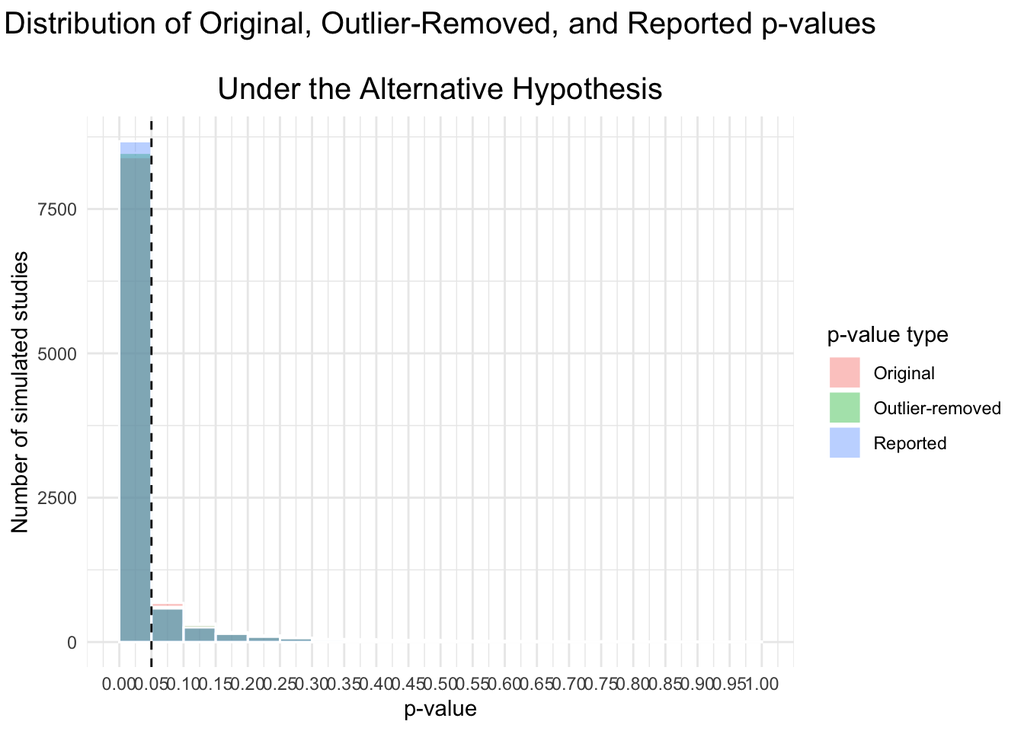

```r
# Alternative hypothesis
# Plot the distribution of p-values under original, outlier-removed, and
# reported analysis
alternative_p_long <- alternative_outlier_results %>%
  select(
    study,
    p_value_original,
    p_value_outlier,
    p_value_reported
  ) %>%
  pivot_longer(
    cols = c(
      p_value_original,
      p_value_outlier,
      p_value_reported
    ),
    names_to = "p_value_type",
    values_to = "p_value"
  ) %>%
  mutate(
    p_value_type = recode(
      p_value_type,
      p_value_original = "Original",
      p_value_outlier = "Outlier-removed",
      p_value_reported = "Reported"
    )
  )

ggplot(
  alternative_p_long,
  aes(
    x = p_value,
    fill = p_value_type
  )
) +
  geom_histogram(
    binwidth = 0.05,
    boundary = 0,
    position = "identity",
    alpha = 0.4,
    colour = "white"
  ) +
  geom_vline(
    xintercept = 0.05,
    linetype = "dashed"
  ) +
  labs(
    title = "Distribution of Original, Outlier-Removed, and Reported p-values
    \nUnder the Alternative Hypothesis",
    x = "p-value",
    y = "Number of simulated studies",
    fill = "p-value type"
  ) +
  scale_x_continuous(
    breaks = seq(0, 1, 0.05)
  ) +
  theme_minimal() +
  theme(
    plot.title = element_text(size = 15, hjust = 0.5),
    plot.subtitle = element_text(size = 13, hjust = 0.5),
    legend.position = "right"
  )
```

```r
# Inspect a case of reported p values under null hypothesis
null_outlier_results %>%
  filter(study == 1) %>%
  select(
    study,
    p_value_original,
    p_value_outlier,
    p_value_reported
  )
```

```
## # A tibble: 1 × 4
##   study p_value_original p_value_outlier p_value_reported
##   <int>            <dbl>           <dbl>            <dbl>
## 1     1           0.0726           0.111           0.0726
```

## Since the p value without outlier removal is lower, we decided

## to report this one under null hypothesis

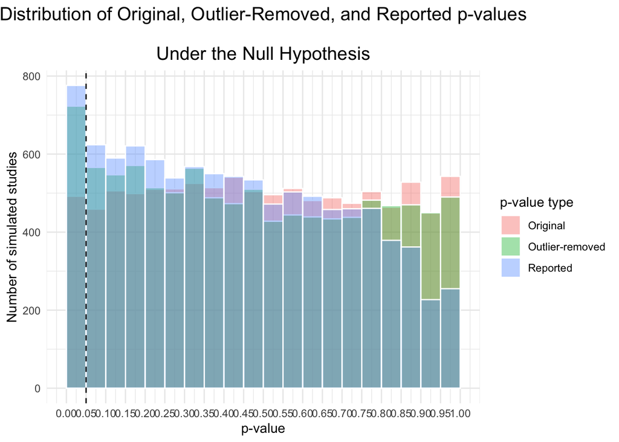

```r
# Null hypothesis
# Plot the distribution of p-values under original, outlier-removed, and
# reported analysis
null_p_long <- null_outlier_results %>%
  select(
    study,
    p_value_original,
    p_value_outlier,
    p_value_reported
  ) %>%
  pivot_longer(
    cols = c(
      p_value_original,
      p_value_outlier,
      p_value_reported
    ),
    names_to = "p_value_type",
    values_to = "p_value"
  ) %>%
  mutate(
    p_value_type = recode(
      p_value_type,
      p_value_original = "Original",
      p_value_outlier = "Outlier-removed",
      p_value_reported = "Reported"
    )
  )

ggplot(
  null_p_long,
  aes(
    x = p_value,
    fill = p_value_type
  )
) +
  geom_histogram(
    binwidth = 0.05,
    boundary = 0,
    position = "identity",
    alpha = 0.4,
    colour = "white"
  ) +
  geom_vline(
    xintercept = 0.05,
    linetype = "dashed"
  ) +
  labs(
    title = "Distribution of Original, Outlier-Removed, and Reported p-values
    \nUnder the Null Hypothesis",
    x = "p-value",
    y = "Number of simulated studies",
    fill = "p-value type"
  ) +
  scale_x_continuous(
    breaks = seq(0, 1, 0.05)
  ) +
  theme_minimal() +
  theme(
    plot.title = element_text(size = 15, hjust = 0.5),
    legend.position = "right"
  )
```

# 2.5 Estimated-effects distributions

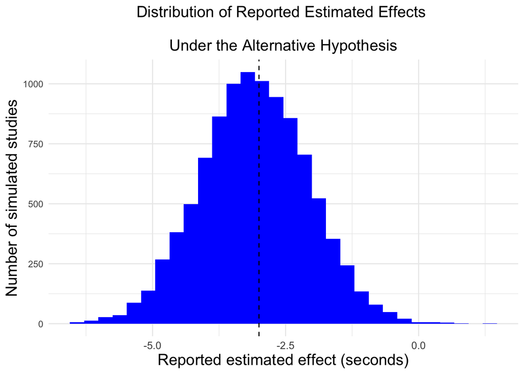

```r
# Alternative distributions
# Plot the distribution of reported estimated effects
ggplot(alternative_outlier_results, aes(x = estimated_effect_reported)) +
  geom_histogram(
    bins = 30,
    fill = "blue"
  ) +
  geom_vline(
    xintercept = effect_size,
    linetype = "dashed"
  ) +
  labs(
    title = "Distribution of Reported Estimated Effects
    \nUnder the Alternative Hypothesis",
    x = "Reported estimated effect (seconds)",
    y = "Number of simulated studies"
  ) +
  theme_minimal() +
  theme(
    plot.title = element_text(size = 15, hjust = 0.5),
    axis.text.x = element_text(size = 10),
    axis.title = element_text(size = 15)
  )
```

```r
# Calculate the mean, standard deviation and central 95%
# of the reported estimated effects under the alternative hypothesis
mean(alternative_outlier_results$estimated_effect_reported)
```

```
## [1] -3.083842
```

```r
sd(alternative_outlier_results$estimated_effect_reported)
```

```
## [1] 1.008267
```

```r
quantile(
  alternative_outlier_results$estimated_effect_reported,
  c(.025, .975)
)
```

```
##      2.5%     97.5%
## -5.047936 -1.123235
```

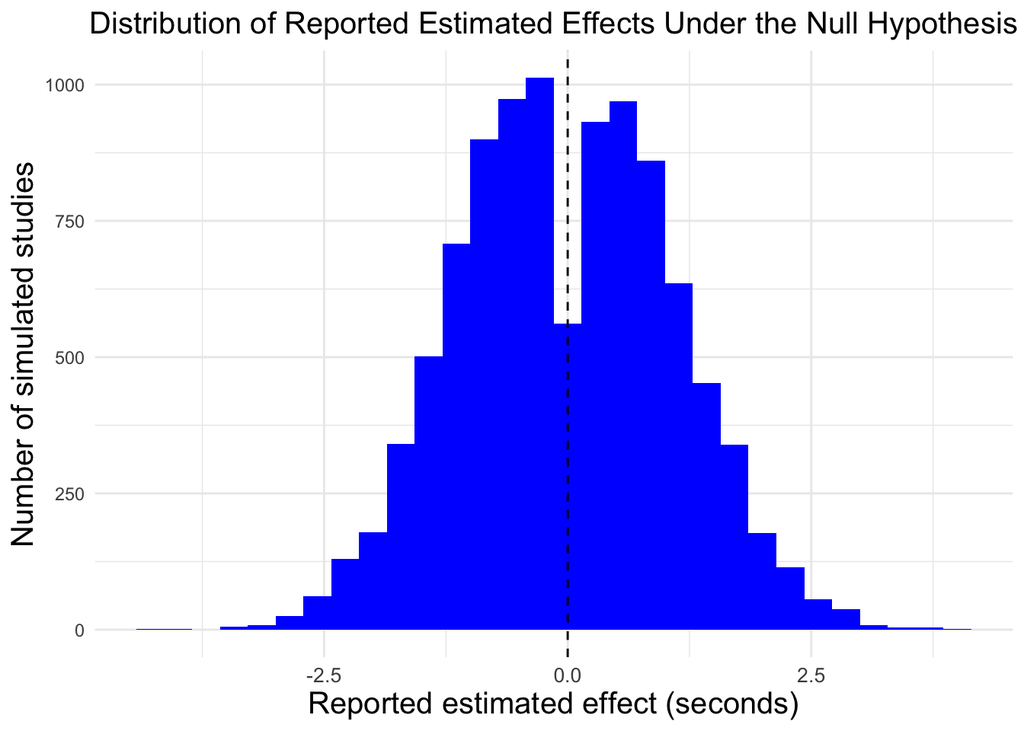

```r
# Null distributions
# Plot the distribution of reported estimated effects under the null hypothesis
ggplot(null_outlier_results, aes(x = estimated_effect_reported)) +
  geom_histogram(
    bins = 30,
    fill = "blue"
  ) +
  geom_vline(
    xintercept = null_effect,
    linetype = "dashed"
  ) +
  labs(
    title = "Distribution of Reported Estimated Effects Under the Null Hypothesis",
    x = "Reported estimated effect (seconds)",
    y = "Number of simulated studies"
  ) +
  theme_minimal() +
  theme(
    plot.title = element_text(size = 15, hjust = 0.5),
    axis.text.x = element_text(size = 10),
    axis.title = element_text(size = 15)
  )
```

```r
# Calculate the mean, standard deviation and central 95%
# of estimated effects in null hypothesis after outlier removal
mean(null_outlier_results$estimated_effect_reported)
```

```
## [1] -0.02222424
```

```r
sd(null_outlier_results$estimated_effect_reported)
```

```
## [1] 1.098578
```

```r
quantile(
  null_outlier_results$estimated_effect_reported,
  c(.025, .975)
)
```

```
##      2.5%     97.5%
## -2.105117  2.087847
```

# 3. QRP-2: Round-down p-values

## using the data from Part C

# 3.1 Round down p-values

```r
# Round down p-values to two decimal places
alternative_round_results <- alternative_results %>%
  mutate(
    p_value_rounded = floor(p_value * 100) / 100
  )

null_round_results <- null_results %>%
  mutate(
    p_value_rounded = floor(p_value * 100) / 100
  )
```

# 3.2 Type I error, Type II error, and Power

```r
# Calculate Type I error after rounding down p-values
# We use <= 0.05 because a rounded p-value of exactly 0.05
# is treated as statistically significant in this QRP

type_I_error_round <- mean(
  null_round_results$p_value_rounded <= 0.05
)

# Calculate Type II error after rounding down p-values
type_II_error_round <- mean(
  alternative_round_results$p_value_rounded > 0.05
)

# Calculate statistical power after rounding down p-values
power_round <- mean(
  alternative_round_results$p_value_rounded <= 0.05
)

type_I_error_round
```

```
## [1] 0.0576
```

```r
type_II_error_round
```

```
## [1] 0.1393
```

```r
power_round
```

```
## [1] 0.8607
```

```r
# check: Type II error and power should add up to approximately 1
type_II_error_round + power_round
```

```
## [1] 1
```

```r
# Create a summary table of the main simulation results:
round_summary <- tibble(
  measure = c(
    "Type I error",
    "Type II error",
    "Statistical power"
  ),
  Part_C = c(
    type_I_error,
    type_II_error,
    power
  ),
  QRP_2_Round_Down = c(
    type_I_error_round,
    type_II_error_round,
    power_round
  )
)

round_summary
```

```
## # A tibble: 3 × 3
##   measure           Part_C QRP_2_Round_Down
##   <chr>              <dbl>            <dbl>
## 1 Type I error      0.0492           0.0576
## 2 Type II error     0.160            0.139
## 3 Statistical power 0.840            0.861
```

# 3.3 P-value distributions

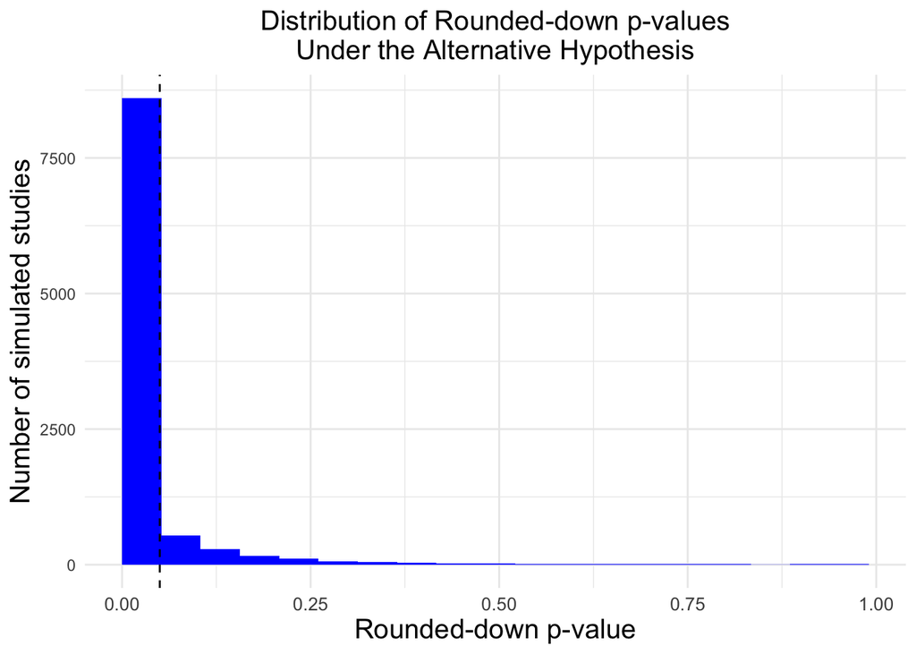

```r
# Alternative distributions
# Plot the distribution of rounded-down p-values
ggplot(alternative_round_results, aes(x = p_value_rounded)) +
  geom_histogram(
    bins = 20,
    boundary = 0,
    fill = "blue"
  ) +
  geom_vline(
    xintercept = 0.05,
    linetype = "dashed"
  ) +
  labs(
    title = "Distribution of Rounded-down p-values\nUnder the Alternative Hypothesis",
    x = "Rounded-down p-value",
    y = "Number of simulated studies"
  ) +
  theme_minimal() +
  theme(
    plot.title = element_text(size = 15, hjust = 0.5),
    axis.text.x = element_text(size = 10),
    axis.title = element_text(size = 15)
  )
```

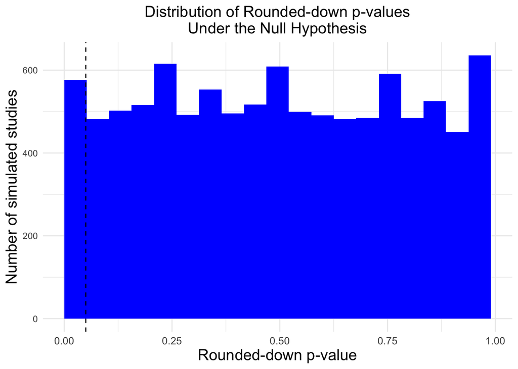

```r
# Null hypothesis
# Plot the distribution of rounded-down p-values
ggplot(null_round_results, aes(x = p_value_rounded)) +
  geom_histogram(
    bins = 20,
    boundary = 0,
    fill = "blue"
  ) +
  geom_vline(
    xintercept = 0.05,
    linetype = "dashed"
  ) +
  labs(
    title = "Distribution of Rounded-down p-values\nUnder the Null Hypothesis",
    x = "Rounded-down p-value",
    y = "Number of simulated studies"
  ) +
  theme_minimal() +
  theme(
    plot.title = element_text(size = 15, hjust = 0.5),
    axis.text.x = element_text(size = 10),
    axis.title = element_text(size = 15)
  )
```

# 4. Estimated-effects distributions

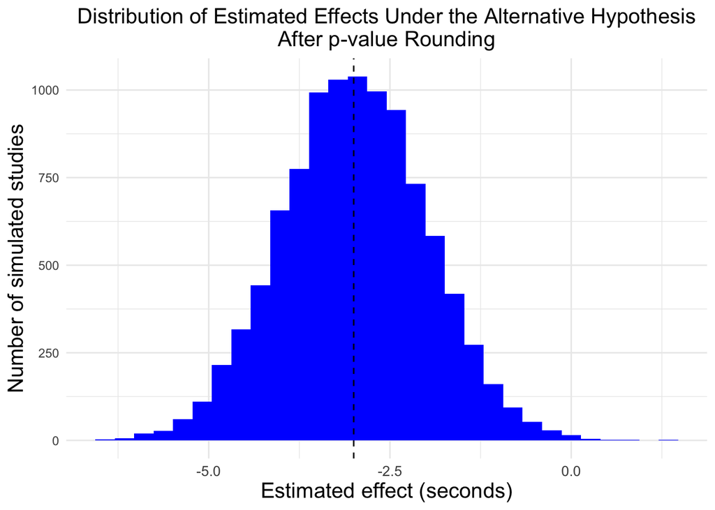

```r
# Alternative hypothesis
# The round-down p-value QRP does not change the data
# or the estimated effect
ggplot(alternative_round_results, aes(x = estimated_effect)) +
  geom_histogram(
    bins = 30,
    fill = "blue"
  ) +
  geom_vline(
    xintercept = -3,
    linetype = "dashed"
  ) +
  labs(
    title = "Distribution of Estimated Effects Under the Alternative Hypothesis\nAfter p-value Rounding",
    x = "Estimated effect (seconds)",
    y = "Number of simulated studies"
  ) +
  theme_minimal() +
  theme(
    plot.title = element_text(size = 15, hjust = 0.5),
    axis.text.x = element_text(size = 10),
    axis.title = element_text(size = 15)
  )
```

```r
# Summary statistics for the estimated effects
mean(alternative_round_results$estimated_effect)
```

```
## [1] -2.989953
```

```r
sd(alternative_round_results$estimated_effect)
```

```
## [1] 0.9950964
```

```r
quantile(
  alternative_round_results$estimated_effect,
  c(.025, .975)
)
```

```
##      2.5%     97.5%
## -4.930234 -1.048890
```

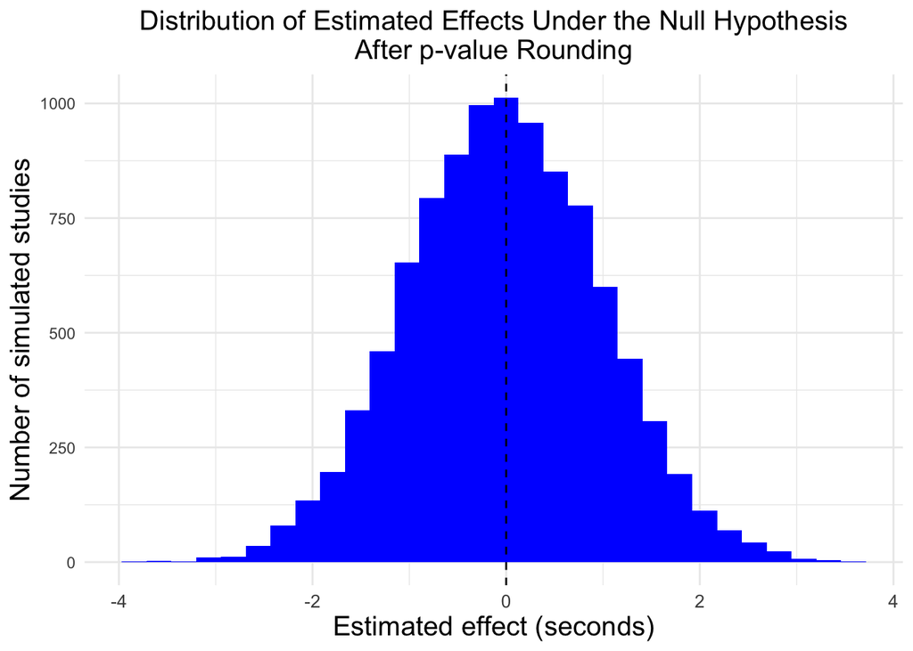

```r
# Null hypothesis
# Plot the distribution of estimated effects under the null hypothesis
ggplot(null_round_results, aes(x = estimated_effect)) +
  geom_histogram(
    bins = 30,
    fill = "blue"
  ) +
  geom_vline(
    xintercept = 0,
    linetype = "dashed"
  ) +
  labs(
    title = "Distribution of Estimated Effects Under the Null Hypothesis\nAfter p-value Rounding",
    x = "Estimated effect (seconds)",
    y = "Number of simulated studies"
  ) +
  theme_minimal() +
  theme(
    plot.title = element_text(size = 15, hjust = 0.5),
    axis.text.x = element_text(size = 10),
    axis.title = element_text(size = 15)
  )
```

# 4. Final Comparison

```r
all_results_comparison <- tibble(
  measure = c(
    "Type I error",
    "Type II error",
    "Statistical power"
  ),
  Part_C = c(
    type_I_error,
    type_II_error,
    power
  ),
  QRP_1_Outlier_Removal = c(
    type_I_error_outlier,
    type_II_error_outlier,
    power_outlier
  ),
  QRP_2_Round_Down = c(
    type_I_error_round,
    type_II_error_round,
    power_round
  )
)

all_results_comparison
```

```
## # A tibble: 3 × 4
##   measure           Part_C QRP_1_Outlier_Removal QRP_2_Round_Down
##   <chr>              <dbl>                 <dbl>            <dbl>
## 1 Type I error      0.0492                0.0776           0.0576
## 2 Type II error     0.160                 0.133            0.139
## 3 Statistical power 0.840                 0.867            0.861
```